# NFL Players Search Engine

## 0. Overview of Code Snippets for Database Design and API Data Fetching

- **MongoDB Setup**:
  - Initialize a MongoDB database to store detailed player data.
  - Insert player statistics and team data fetched from the Sportsdata.io API into MongoDB.
- **PostgreSQL Setup**:
  - Establish a PostgreSQL database to hold structured player game statistics.
  - Create and maintain a table schema that supports storing comprehensive game-related metrics such as passing yards, rushing yards, and fantasy points.
- **Data Fetching from API**:
  - Retrieve player statistics by week and season from the Sportsdata.io API and insert this data into the PostgreSQL database.
  - Handle specific player queries (e.g., Lamar Jackson's stats for 2023) using PostgreSQL, demonstrating database querying capabilities and data extraction.
- **Direct API Calls for News**:
  - Test direct API calls to fetch and display the latest NFL news, focusing on handling JSON data and managing API responses effectively.

## 1. Fetch and Insert NFL Team Player Data into MongoDB

```python
from pymongo import MongoClient
import requests
import time

# Function to fetch and insert player data for a given team
def fetch_and_insert_team_data(team, api_key, collection):
    url = f"https://api.sportsdata.io/v3/nfl/scores/json/Players/{team}?key={api_key}"
    response = requests.get(url)

    if response.status_code == 200:
        players_data = response.json()
        if players_data:  # Check if the list is not empty
            result = collection.insert_many(players_data)
            print(f"Inserted {len(result.inserted_ids)} documents for team {team} into MongoDB.")
        else:
            print(f"No data to insert for team {team}.")
    else:
        print(f"Failed to fetch data for team {team}. Status Code: {response.status_code}")

# MongoDB setup
client = MongoClient('localhost', 27017)
db = client.nfl
collection = db.players

# API key
api_key = '2c96346235e54c7f9f7542fc3e69d6da'

# List of NFL team abbreviations
teams = ["ARI", "ATL", "BAL", "BUF", "CAR", "CHI", "CIN", "CLE", "DAL", "DEN", "DET", "GB", "HOU", "IND", "JAX", "KC", "LAC", "LAR", "LV", "MIA", "MIN", "NE", "NO", "NYG", "NYJ", "PHI", "PIT", "SEA", "SF", "TB", "TEN", "WAS"]

# Iterate over each team and fetch/insert their player data
for team in teams:
    fetch_and_insert_team_data(team, api_key, collection)
    time.sleep(5)  # Short sleep to avoid hitting the rate limit; adjust as needed based on API guidelines

print("Data fetching and insertion completed.")
```

```
Inserted 77 documents for team ARI into MongoDB.
Inserted 66 documents for team ATL into MongoDB.
Inserted 59 documents for team BAL into MongoDB.
Inserted 63 documents for team BUF into MongoDB.
Inserted 70 documents for team CAR into MongoDB.
Inserted 68 documents for team CHI into MongoDB.
Inserted 60 documents for team CIN into MongoDB.
Inserted 75 documents for team CLE into MongoDB.
Inserted 63 documents for team DAL into MongoDB.
Inserted 71 documents for team DEN into MongoDB.
Inserted 64 documents for team DET into MongoDB.
Inserted 68 documents for team GB into MongoDB.
Inserted 76 documents for team HOU into MongoDB.
Inserted 76 documents for team IND into MongoDB.
Inserted 69 documents for team JAX into MongoDB.
Inserted 72 documents for team KC into MongoDB.
Inserted 56 documents for team LAC into MongoDB.
Inserted 62 documents for team LAR into MongoDB.
Inserted 62 documents for team LV into MongoDB.
Inserted 67 documents for team MIA into MongoDB.
Inserted 67 documents for team MIN into MongoDB.
Inserted 69 documents for team NE into MongoDB.
Inserted 63 documents for team NO into MongoDB.
Inserted 71 documents for team NYG into MongoDB.
Inserted 67 documents for team NYJ into MongoDB.
Inserted 76 documents for team PHI into MongoDB.
Inserted 74 documents for team PIT into MongoDB.
Inserted 65 documents for team SEA into MongoDB.
Inserted 75 documents for team SF into MongoDB.
Inserted 68 documents for team TB into MongoDB.
Inserted 64 documents for team TEN into MongoDB.
Inserted 65 documents for team WAS into MongoDB.
Data fetching and insertion completed.
```

- **API Interaction**: Utilizes the Sportsdata.io API to fetch player data for each NFL team using the team's abbreviation.
- **MongoDB Integration**: Inserts the fetched data into a MongoDB collection named `players`, which resides within the `nfl` database.
- **Data Handling**: Checks if the API call is successful and if data is available, then proceeds to insert it. Otherwise, it outputs an appropriate error message.
- **Rate Limit Management**: Implements a delay (sleep) between API calls to comply with rate limits and avoid potential blocking by the API provider.
- **Team Iteration**: Iterates over a list of all NFL team abbreviations, performing the fetch and insert operation for each team. Feedback: Provides feedback on the number of documents inserted for each team or errors encountered during the process.

[figure not shown]

## 2. Retrieve and Display Player Information: Lamar Jackson

```python
# Search for Lamar Jackson's information
player_info = collection.find_one({"FirstName": "Lamar", "LastName": "Jackson"})

if player_info:
    # Print all found information
    for key, value in player_info.items():
        print(f"{key}: {value}")
else:
    print("No information found for Lamar Jackson.")
```

```
_id: 66064e2433ed18497de73aa8
PlayerID: 19781
Team: BAL
Number: 8
FirstName: Lamar
LastName: Jackson
Position: QB
Status: Active
Height: 6'2"
Weight: 215
BirthDate: 1997-01-07T00:00:00
College: Louisville
Experience: 2
FantasyPosition: QB
Active: True
PositionCategory: OFF
Name: Lamar Jackson
Age: 27
ExperienceString: 7th Season
BirthDateString: January 7, 1997
PhotoUrl: https://s3-us-west-2.amazonaws.com/static.fantasydata.com/headshots/nfl/low-res/19781.png
ByeWeek: 13
UpcomingGameOpponent: KC
UpcomingGameWeek: 0
ShortName: L.Jackson
AverageDraftPosition: 19.1
DepthPositionCategory: Scrambled
DepthPosition: Scrambled
DepthOrder: 0
DepthDisplayOrder: 0
CurrentTeam: BAL
CollegeDraftTeam: BAL
CollegeDraftYear: 2018
CollegeDraftRound: 0
CollegeDraftPick: 17
IsUndraftedFreeAgent: False
HeightFeet: 6
HeightInches: 2
UpcomingOpponentRank: 0
UpcomingOpponentPositionRank: 3
```

[output cut: 22 more lines]

```
DeclaredInactive: False
UpcomingFanDuelSalary: None
UpcomingDraftKingsSalary: None
UpcomingYahooSalary: None
TeamID: 3
GlobalTeamID: 3
FantasyDraftPlayerID: 877745
FantasyDraftName: Lamar Jackson
UsaTodayPlayerID: 8253800
UsaTodayHeadshotUrl: http://cdn.usatsimg.com/api/download/?imageID=21378928
UsaTodayHeadshotNoBackgroundUrl: http://cdn.usatsimg.com/api/download/?imageID=21378927
UsaTodayHeadshotUpdated: 2023-09-09T11:26:20
UsaTodayHeadshotNoBackgroundUpdated: 2023-09-09T11:26:15
PlayerSeason: None
LatestNews: []
```

- **Query Execution**: Searches the MongoDB `players` collection for a player with the first name "Lamar" and the last name "Jackson".
- **Data Handling**: Checks if the player exists in the database.
- **Output Information**: If the player is found, the script prints all the available details about the player, iterating over each field and its value.
- **No Data Handling**: Provides a message if no information is available for Lamar Jackson in the database.

## 3. Fetch and Display Specific Player Statistics for a Given Week

```python
import requests

def fetch_player_game_stats_by_week(season, week, api_key):
    url = f"https://api.sportsdata.io/v3/nfl/stats/json/PlayerGameStatsByWeek/{season}/{week}?key={api_key}"
    response = requests.get(url)
    if response.status_code == 200:
        players_data = response.json()  # Return all players' data
        return players_data
    else:
        print(f"Failed to fetch data. Status Code: {response.status_code}")
        return None

def main():
    api_key = '2c96346235e54c7f9f7542fc3e69d6da'
    season = "2023REG"
    week = 1
    player_id = 19781  # Lamar Jackson's PlayerID

    # Fetch the data
    players_data = fetch_player_game_stats_by_week(season, week, api_key)

    # Filter for Lamar Jackson's data
    if players_data:
        lamar_data = next((player for player in players_data if player["PlayerID"] == player_id), None)
        if lamar_data:
            print("Lamar Jackson's Game Stats:")
            for key, value in lamar_data.items():
                print(f"{key}: {value}")
        else:
            print("No data found for Lamar Jackson.")
    else:
        print("No data returned from API.")

if __name__ == "__main__":
    main()
```

```
Lamar Jackson's Game Stats:
GameKey: 202310103
PlayerID: 19781
SeasonType: 1
Season: 2023
GameDate: 2023-09-10T13:00:00
Week: 1
Team: BAL
Opponent: HOU
HomeOrAway: HOME
Number: 8
Name: Lamar Jackson
Position: QB
PositionCategory: OFF
Activated: 1
Played: 1
Started: 1
PassingAttempts: 2.0
PassingCompletions: 1.6
PassingYards: 51.5
PassingCompletionPercentage: 23.6
PassingYardsPerAttempt: 0.7
PassingYardsPerCompletion: 0.9
PassingTouchdowns: 0.0
PassingInterceptions: 0.1
PassingRating: 24.3
PassingLong: 2.7
PassingSacks: 0.4
PassingSackYards: 1.3
RushingAttempts: 0.6
RushingYards: 11.6
RushingYardsPerAttempt: 0.6
RushingTouchdowns: 0.0
RushingLong: 1.3
ReceivingTargets: 0.0
Receptions: 0.0
ReceivingYards: 0.0
ReceivingYardsPerReception: 0.0
ReceivingTouchdowns: 0.0
ReceivingLong: 0.0
```

[output cut: 115 more lines]

```
FantasyDraftSalary: None
FantasyDraftPosition: None
TeamID: 3
OpponentID: 13
Day: 2023-09-10T00:00:00
DateTime: 2023-09-10T13:00:00
GlobalGameID: 18493
GlobalTeamID: 3
GlobalOpponentID: 13
ScoreID: 18493
FantasyPointsFantasyDraft: 0.8
OffensiveFumbleRecoveryTouchdowns: None
SnapCountsConfirmed: True
Updated: 2023-09-15T13:00:04
ScoringDetails: []
```

- **API Request**: Sends a request to the NFL statistics API to get data for all players in a specified week of the 2023 regular season.
- **Data Filtering**: After fetching the data, it filters for Lamar Jackson using his unique PlayerID (19781).
- **Display Data**: If Lamar Jackson's data is found, prints each attribute and its value.
- **Error Handling**: Provides feedback if no data is returned for Lamar Jackson or if the API request fails.

## 4. Creating a PostgreSQL Database Table for NFL Player Game Stats

```python
import psycopg

# Define the SQL statement to create the table
create_table_query = """
CREATE TABLE IF NOT EXISTS player_game_stats (
    GamePlayerKey TEXT PRIMARY KEY,
    GameKey TEXT NOT NULL,
    PlayerID INTEGER NOT NULL,
    Name TEXT,
    Position TEXT,
    Team TEXT,
    Opponent TEXT,
    GameDate DATE,
    Week INTEGER,
    Season INTEGER,
    PassingYards INTEGER,
    RushingYards INTEGER,
    ReceivingYards INTEGER,
    Touchdowns INTEGER,
    Interceptions INTEGER,
    Fumbles INTEGER,
    Tackles INTEGER,
    Sacks INTEGER,
    FantasyPoints REAL,
    FantasyPointsPPR REAL,
    FantasyPointsYahoo REAL,
    HomeOrAway TEXT
);
"""

def create_table(conn):
    with conn.cursor() as cur:
        cur.execute(create_table_query)
        conn.commit()
        print("Table created successfully.")

def main():
    conn = psycopg.connect(
        host="localhost",
        dbname="my_database",
        user="postgres",
        password=""
    )

    # Create the table
    create_table(conn)

    # Close the connection
    conn.close()

if __name__ == "__main__":
    main()
```

```
Table created successfully.
```

- **SQL Table Definition**: Outlines the SQL query for creating a table named `player_game_stats`. This table is equipped with fields specifically designed to record various metrics crucial for calculating fantasy points, such as `Passing Yards`, `Receiving Yards`, `Touchdowns`, and more, providing a detailed view of player performances essential for fantasy sports analysis.
- **Database Connection and Table Creation**: Establishes a connection to the PostgreSQL database, executes the table creation command, and commits the changes to ensure the table is added to the database.
- **Feedback on Operation**: Provides a print statement to confirm the successful creation of the table.
- **Connection Management**: Ensures that the database connection is properly closed after the operation to prevent leaks.

## 5. Automating Data Retrieval and Storage for NFL Player Game Statistics

```python
import requests
import psycopg

def fetch_player_game_stats_by_week(season, week, api_key):
    url = f"https://api.sportsdata.io/v3/nfl/stats/json/PlayerGameStatsByWeek/{season}/{week}?key={api_key}"
    response = requests.get(url)
    if response.status_code == 200:
        players_data = response.json()  # Return all players' data
        for player in players_data:
            player['Season'] = season[:4]  # Extract year from season string, e.g., '2023REG' -> '2023'
        return players_data
    else:
        print(f"Failed to fetch data. Status Code: {response.status_code}")
        return []

def insert_data_into_postgres(players_data, conn):
    with conn.cursor() as cur:
        for player_data in players_data:
            # Create a unique key for each player-game instance
            player_data['GamePlayerKey'] = f"{player_data['GameKey']}-{player_data['PlayerID']}"

            # Prepare the INSERT statement
            query = """
            INSERT INTO player_game_stats (
                GamePlayerKey, GameKey, PlayerID, Season, Name, Position, Team, Opponent, GameDate, Week,
                PassingYards, RushingYards, ReceivingYards, Touchdowns, Interceptions,
                Fumbles, Tackles, Sacks, FantasyPoints, FantasyPointsPPR,
                FantasyPointsYahoo, HomeOrAway
            ) VALUES (
                %(GamePlayerKey)s, %(GameKey)s, %(PlayerID)s, %(Season)s, %(Name)s, %(Position)s, %(Team)s, %(Opponent)s,
                %(GameDate)s, %(Week)s, %(PassingYards)s, %(RushingYards)s,
                %(ReceivingYards)s, %(Touchdowns)s, %(Interceptions)s, %(Fumbles)s,
                %(Tackles)s, %(Sacks)s, %(FantasyPoints)s, %(FantasyPointsPPR)s,
                %(FantasyPointsYahoo)s, %(HomeOrAway)s
            )
            ON CONFLICT (GamePlayerKey) DO NOTHING;
            """
            # Execute the query for the current player's data
            cur.execute(query, player_data)

    # Commit all inserts
    conn.commit()
    print(f"Inserted stats for {len(players_data)} players into the database.")

def main():
    api_key = '2c96346235e54c7f9f7542fc3e69d6da'
    conn = psycopg.connect(
        host="localhost",
        dbname="my_database",
        user="postgres",
        password=""
    )

    seasons = {
        '2020REG': 17,
        '2021REG': 18,
        '2022REG': 18,
        '2023REG': 18,
    }

    # Loop through all seasons and weeks
    for season, weeks in seasons.items():
        for week in range(1, weeks + 1):
            print(f"Fetching data for {season} week {week}")
            players_data = fetch_player_game_stats_by_week(season, week, api_key)
            if players_data:
                insert_data_into_postgres(players_data, conn)

    # Close the connection
    conn.close()

if __name__ == "__main__":
    main()
```

```
Fetching data for 2020REG week 1
Inserted stats for 1809 players into the database.
Fetching data for 2020REG week 2
Inserted stats for 1815 players into the database.
Fetching data for 2020REG week 3
Inserted stats for 1810 players into the database.
Fetching data for 2020REG week 4
Inserted stats for 1705 players into the database.
Fetching data for 2020REG week 5
Inserted stats for 1595 players into the database.
Fetching data for 2020REG week 6
Inserted stats for 1612 players into the database.
Fetching data for 2020REG week 7
Inserted stats for 1611 players into the database.
Fetching data for 2020REG week 8
Inserted stats for 1621 players into the database.
Fetching data for 2020REG week 9
Inserted stats for 1636 players into the database.
Fetching data for 2020REG week 10
Inserted stats for 1621 players into the database.
Fetching data for 2020REG week 11
Inserted stats for 1635 players into the database.
Fetching data for 2020REG week 12
Inserted stats for 1879 players into the database.
Fetching data for 2020REG week 13
Inserted stats for 1736 players into the database.
Fetching data for 2020REG week 14
Inserted stats for 1872 players into the database.
Fetching data for 2020REG week 15
Inserted stats for 1879 players into the database.
Fetching data for 2020REG week 16
Inserted stats for 1884 players into the database.
Fetching data for 2020REG week 17
Inserted stats for 1906 players into the database.
Fetching data for 2021REG week 1
Inserted stats for 1737 players into the database.
Fetching data for 2021REG week 2
Inserted stats for 1726 players into the database.
Fetching data for 2021REG week 3
Inserted stats for 1730 players into the database.
```

[output cut: 87 more lines]

```
Inserted stats for 1536 players into the database.
Fetching data for 2023REG week 12
Inserted stats for 1754 players into the database.
Fetching data for 2023REG week 13
Inserted stats for 1419 players into the database.
Fetching data for 2023REG week 14
Inserted stats for 1640 players into the database.
Fetching data for 2023REG week 15
Inserted stats for 1747 players into the database.
Fetching data for 2023REG week 16
Inserted stats for 1759 players into the database.
Fetching data for 2023REG week 17
Inserted stats for 1757 players into the database.
Fetching data for 2023REG week 18
Inserted stats for 1762 players into the database.
```

- **API Data Fetching**: The script uses the `requests` library to fetch player game statistics from the SportsData.io API based on the season and week.
- **Data Processing**: Enhances data by appending the season year to each player's records directly fetched from the API, making it more meaningful for storage and analysis.
- **Database Interaction**: Utilizes the `psycopg` library to connect to a PostgreSQL database and insert the fetched data. It constructs a unique key for each player-game instance to avoid duplicates.
- **Robust Error Handling**: Includes error checking to handle API failures and ensures data integrity during the database insertion process.
- **Automation and Scheduling**: The script is designed to loop through predefined NFL seasons and weeks, allowing for automated, scheduled runs to continuously update the database with new data.

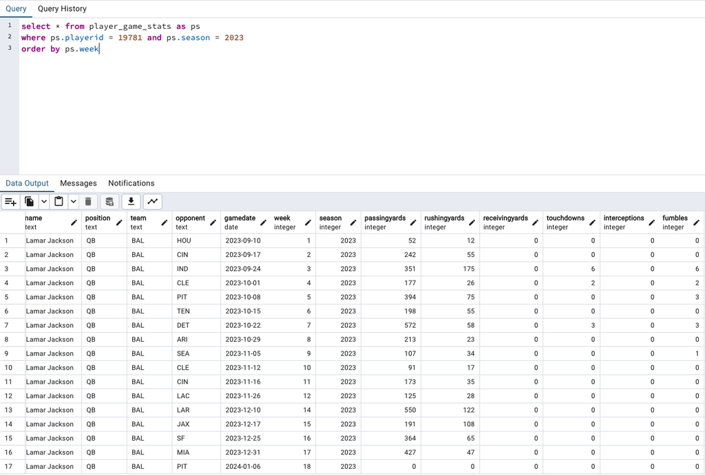

## 6. Fetch and Display Top NFL News

```python
import requests

def fetch_and_print_league_news(api_key):
    league_url = f"https://api.sportsdata.io/v3/nfl/scores/json/News?key={api_key}"
    response = requests.get(league_url)
    if response.status_code == 200:
        news_items = response.json()[:5]
        for news in news_items:
            title = news.get('Title', 'No Title Available')
            time_ago = news.get('TimeAgo', 'No Time Info')
            print(f"Title: {title}, Time Ago: {time_ago}")
    else:
        print(f"Failed to fetch news data. Status Code: {response.status_code}")

api_key = '2c96346235e54c7f9f7542fc3e69d6da'
fetch_and_print_league_news(api_key)
```

```
Title: Rashee Rice Surrenders To Police, Time Ago: 4 hours ago
Title: Browns, Nick Chubb Agree To Reworked Contract, Time Ago: yesterday
Title: Jaguars, Josh  Allen Agree On Five-Year Extension, Time Ago: 2 days ago
Title: Eagles-Packers Could Face Off In Brazil In Week 1, Time Ago: 3 days ago
Title: Holdout Could Be Coming For CeeDee Lamb, Time Ago: 4 days ago
```

- **API Request**: The script makes an HTTP GET request to the News endpoint of the Sportsdata.io NFL API to fetch the latest news data.
- **Data Handling**: After retrieving the news data in JSON format, it limits the results to the top five items for immediate display.
- **Output**: For each news item, it extracts and prints the title and the time ago information, providing a quick overview of recent NFL developments.
- **Error Handling**: If the API request fails (e.g., due to a network issue or an API limit), the script will output the corresponding HTTP status code to aid in troubleshooting.

## 7. app.py Execution Deliverables

- **Interactive Web Interface**:
  - Launches a web application that allows users to interactively search for NFL players by name and season.
- **Dynamic Data Retrieval**:
  - Retrieves player information from a MongoDB database based on user input.
  - Fetches detailed player statistics for a specific season from a PostgreSQL database.
- **Data Visualization**:
  - Displays player statistics in tabular format, enhancing readability and comparison.
  - Integrates a line graph to visualize the player's Fantasy Points Per Reception (PPR) over the weeks of a season using Chart.js.
- **Real-time NFL News**:
  - Fetches and displays the latest NFL news from an external API, showcasing headlines and timestamps dynamically.
- **Styling and Layout**:
  - Utilizes custom CSS for styling, ensuring that the interface is user-friendly and visually appealing.
  - Implements responsive design elements to ensure compatibility across different devices and screen sizes.

```python
# Open and read the app.py file
file_path = 'app.py'
with open(file_path, 'r') as file:
    app_py_content = file.read()
print(app_py_content)
```

```
from flask import Flask, request, render_template_string
from pymongo import MongoClient
import psycopg
import requests

# Constants and configurations
API_KEY = '2c96346235e54c7f9f7542fc3e69d6da'
MONGO_URI = 'localhost'
MONGO_PORT = 27017
PSQL_HOST = "localhost"
PSQL_DB = "my_database"
PSQL_USER = "postgres"
PSQL_PASS = ""
STATIC_URL_PATH = ''
STATIC_FOLDER = 'static'
APP_PORT = 5010

app = Flask(__name__, static_url_path=STATIC_URL_PATH, static_folder=STATIC_FOLDER)

# Database setup
client = MongoClient(MONGO_URI, MONGO_PORT)
db = client.nfl
players_collection = db.players
conn = psycopg.connect(
    host=PSQL_HOST,
    dbname=PSQL_DB,
    user=PSQL_USER,
    password=PSQL_PASS
)

# HTML template
HTML_TEMPLATE = """
<!DOCTYPE html>
<html>
<head>
    <title>NFL Players Search Engine</title>
    <style>
        body { font-family: Arial, sans-serif; text-align: center; }
        h1, h2, h3 { color: #333; }
        p, table { width: 80%; margin: auto; text-align: center; }
```

[output cut: 174 more lines]

```
    if league_response.status_code == 200:
        league_news = league_response.json()[:5]  # Get the top 5 news items for the league

    return render_template_string(
        HTML_TEMPLATE,
        league_news=league_news,
        player_name=player_name,
        player_info=player_info,
        player_stats=player_stats,
        weeks=weeks,
        fantasy_points_ppr=fantasy_points_ppr
    )

if __name__ == '__main__':
    app.run(debug=True, port=5010)
```

[figure not shown]

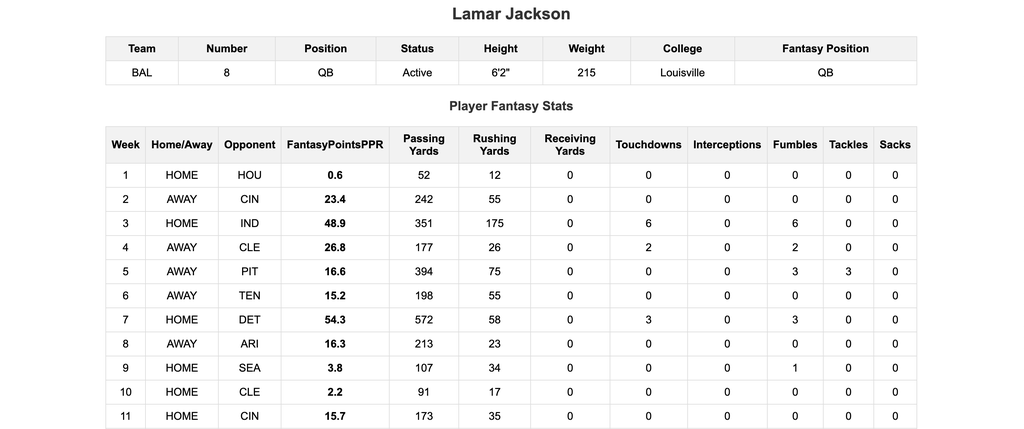

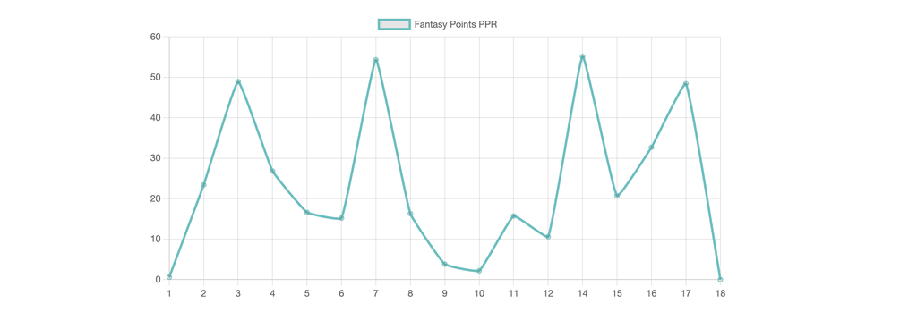